# SVM for urine loss 1-year

Hajar Hasannejadasl

2022-09-02

```r
training= data.frame(allData1year[1])
training=training[,1:38]
test= data.frame(allData1year[2])
test=test[,1:38]
```

Before we start, we’ll first remove the variables related to hot flashes and sensitive breasts as these are not to be included upon request by collaborators.

```r
training = training[,-grep("epic26_22_opvliegers1", names(training))]
training = training[,-grep("epic26_23_gevoeligeborsten1", names(training))]

test = test[,-grep("epic26_22_opvliegers1", names(test))]
test = test[,-grep("epic26_23_gevoeligeborsten1", names(test))]
```

First we recreate the training and test set with only the input variables and the outcome we want, in this case *“epic26_1_urineverlies2”. We’ll also remove the outcome data that we’re not interested in right now from the training and test set.

```r
outcomeTraining = allData1year[[1]]$epic26_1_urineverlies2
outcomeTest = allData1year[[2]]$epic26_1_urineverlies2
```

The test set contains one sample with answer 0 (which means NA). We’ll remove that one first.

```r
test = test[-which(outcomeTest == 0),]
outcomeTest = outcomeTest[-which(outcomeTest == 0)]
```

Now we’ll make our binary data set

```r
#convert to binary
BinaryoutcomeTest<-ifelse(outcomeTest<5, "1","0")
BinaryoutcomeTraining<-ifelse(outcomeTraining<5, "1","0")

#convert to factor
BinaryoutcomeTraining=as.numeric(BinaryoutcomeTraining)
BinaryoutcomeTest=as.factor(BinaryoutcomeTest)
```

Prediction after Upsampling of the smaller dataset Upsampling on class 2 (patients with problems) on train data

```r
#Upsampling

library(smotefamily)
trainingSet2 <- data.frame(cbind(training,BinaryoutcomeTraining))
trainingSet2$BinaryoutcomeTraining <- as.factor(trainingSet2$BinaryoutcomeTraining)
smote <- smotefamily::SMOTE(trainingSet2[,-which(colnames(trainingSet2) == "BinaryoutcomeTraining")], trainingSet2$BinaryoutcomeTraining, K=5, dup_size = 1)
datasmote=smote$data
table(datasmote$class)
```

```
##
##   0   1
## 400 428
```

```r
SMOTE2BinaryOutcomeTraining = (datasmote[,c(37)])
SMOTE2OutcomeTraining = (datasmote[,c(37)])

SMOTE2TrainingSet = datasmote[,-c(37)]
SMOTE2BinaryOutcomeTraining<-as.factor(SMOTE2BinaryOutcomeTraining)
SMOTE2OutcomeTraining<-as.factor(SMOTE2BinaryOutcomeTraining)
```

The SMOTE function has generated 214 syntheic data. The dataset is now almost fully balanced.

#Recursive feature elimination

```r
levels(SMOTE2BinaryOutcomeTraining) <- c("firstclass", "secondclass")

# svmProfile_linear <- rfe(SMOTE2TrainingSet, SMOTE2BinaryOutcomeTraining,
#                      sizes = c(2:36),
#                      rfeControl = rfeControl(functions = caretFuncs,
#                                             number = 5),
#
#                     method = "svmLinear", metric = "Accuracy")


# saveRDS(svmProfile_linear, "C:/Users/hajar.hasannejadasl/Documents/prospect2022/models/SVMProfile-UI-1year.rds")
svmProfile_linear = readRDS("C:/Users/hajar.hasannejadasl/Documents/prospect2022/models/SVMProfile-UI-1year.rds")
```

We’ll now run SVM models based on the variable importance retrieved by RFE.

```r
varImportance = calculateVariableImportance(svmProfile_linear)
```

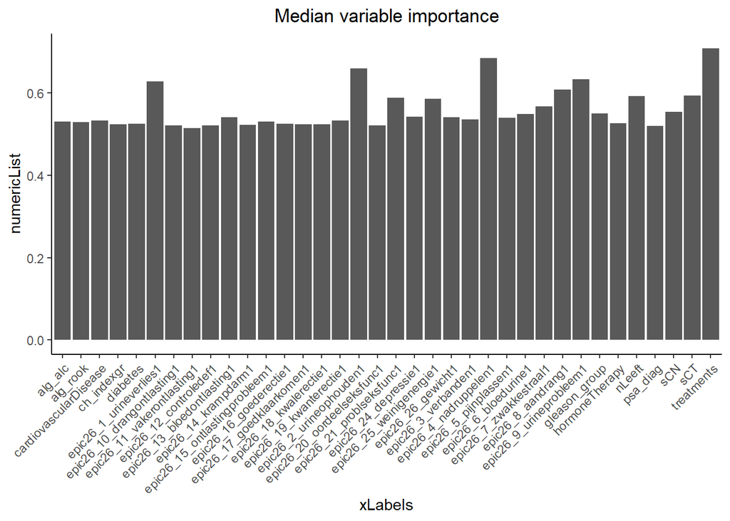

```r
  allSVMModels = reduceVariablesLogit(SMOTE2TrainingSet, SMOTE2BinaryOutcomeTraining, varImportance)
```

```
## [1] 1
## [1] 2
## [1] 3
## [1] 4
## [1] 5
## [1] 6
## [1] 7
## [1] 8
## [1] 9
## [1] 10
## [1] 11
## [1] 12
## [1] 13
## [1] 14
## [1] 15
```

[output cut: 19 more lines]

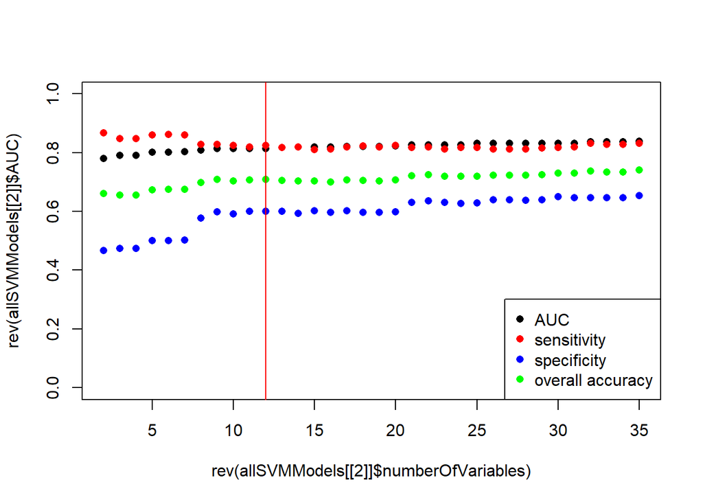

```r
  {plot(rev(allSVMModels[[2]]$numberOfVariables), rev(allSVMModels[[2]]$AUC), ylim = c(0, 1), pch = 16)
    points(rev(allSVMModels[[2]]$numberOfVariables), rev(allSVMModels[[2]]$sensitivity), col = "red",  pch = 16)
    points(rev(allSVMModels[[2]]$numberOfVariables), rev(allSVMModels[[2]]$specificity), col =  "blue",  pch = 16)
    points(rev(allSVMModels[[2]]$numberOfVariables), rev(allSVMModels[[2]]$overallAccuracy), col = "green",  pch = 16)
    abline(v=12, col = "red")
    legend("bottomright", legend = c("AUC", "sensitivity", "specificity", "overall accuracy"), col = c("black", "red", "blue", "green"), pch = 16)}
```

```r
#Checking the performance metrics
allSVMModels[2]
```

```
## [[1]]
##          AUC sensitivity specificity overallAccuracy numberOfVariables
## 1  0.8381250      0.8325   0.6542056       0.7403382                35
## 2  0.8373131      0.8275   0.6471963       0.7342995                34
## 3  0.8371846      0.8275   0.6471963       0.7342995                33
## 4  0.8361741      0.8325   0.6471963       0.7367150                32
## 5  0.8323832      0.8200   0.6471963       0.7306763                31
## 6  0.8322021      0.8175   0.6495327       0.7306763                30
## 7  0.8313902      0.8150   0.6401869       0.7246377                29
## 8  0.8311916      0.8125   0.6378505       0.7222222                28
## 9  0.8313435      0.8125   0.6401869       0.7234300                27
## 10 0.8313668      0.8125   0.6401869       0.7234300                26
## 11 0.8310806      0.8175   0.6285047       0.7198068                25
## 12 0.8267699      0.8175   0.6261682       0.7185990                24
## 13 0.8259346      0.8125   0.6308411       0.7185990                23
```

[output cut: 21 more lines]

We chose the model with 9 variables.

```r
 #ChosenModel
 chosenmodelvariables<-svmProfile_linear$optVariables[1:9]
 chosenmodelvariables
```

```
## [1] "treatments"               "epic26_4_nadruppelen1"
## [3] "epic26_2_urineophouden1"  "epic26_9_urineprobleem1"
## [5] "epic26_1_urineverlies1"   "epic26_8_aandrang1"
## [7] "nLeeft"                   "sCT"
## [9] "epic26_21_problseksfunc1"
```

```r
newdataset<-SMOTE2TrainingSet[c(chosenmodelvariables)]
 #train with chosen variables
 set.seed(350)
 # Fit the model
 combined<-cbind(newdataset,SMOTE2BinaryOutcomeTraining)


#  model_svmRFE<- train(SMOTE2BinaryOutcomeTraining ~ ., data = combined,
#                            method = "svmLinear",
#                            preProcess = c("center", "scale"),
#                            trControl = trainControl(method = "boot", number = 25, classProbs = TRUE, summaryFunction = twoClassSummary, savePredictions = TRUE))
#
# saveRDS(model_svmRFE, "C:/Users/hajar.hasannejadasl/Documents/prospect2022/models/model_svmRFE.rds")
model_svmRFE = readRDS("C:/Users/hajar.hasannejadasl/Documents/prospect2022/models/model_svmRFE.rds")
```

```r
# Linear SVM Performance Evaluation in test set
testcombine<- cbind(test,BinaryoutcomeTest)
testcombine$BinaryoutcomeTest<-as.factor(testcombine$BinaryoutcomeTest)
levels(testcombine$BinaryoutcomeTest) <- c("firstclass", "secondclass")

predict_svmRFE_test <- predict(model_svmRFE, newdata = testcombine,na.action = na.pass)
confusionMatrix(table(predict_svmRFE_test, testcombine$BinaryoutcomeTest))
```

```
## Confusion Matrix and Statistics
##
##
## predict_svmRFE_test firstclass secondclass
##         firstclass         109          18
##         secondclass         45          61
##
##                Accuracy : 0.7296
##                  95% CI : (0.6677, 0.7855)
##     No Information Rate : 0.6609
##     P-Value [Acc > NIR] : 0.014770
##
##                   Kappa : 0.4431
##
##  Mcnemar's Test P-Value : 0.001054
##
##             Sensitivity : 0.7078
##             Specificity : 0.7722
##          Pos Pred Value : 0.8583
##          Neg Pred Value : 0.5755
##              Prevalence : 0.6609
##          Detection Rate : 0.4678
##    Detection Prevalence : 0.5451
##       Balanced Accuracy : 0.7400
##
##        'Positive' Class : firstclass
##
```

```r
test_probSVM = predict(model_svmRFE, testcombine, type = "prob")
roc_svm_one <- roc(BinaryoutcomeTest, as.vector(test_probSVM[,1]), ci=T)
```

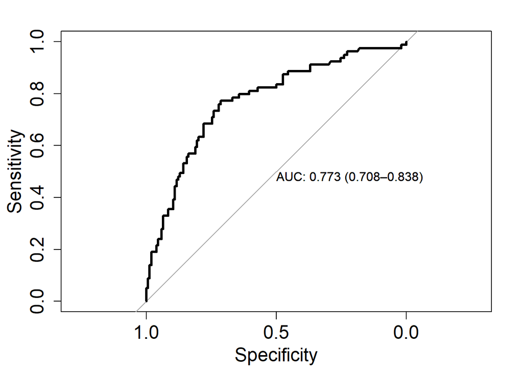

```r
plot(roc_svm_one, col = "black",lty = 1,cex.lab=1.5, cex.axis=1.5, lwd = 3, print.auc=TRUE)
```

#Important Variables

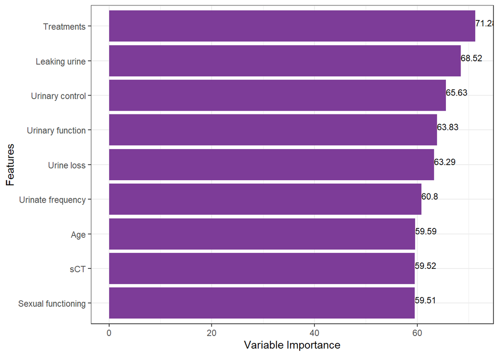

```r
imp <- (varImp(svmProfile_linear))

imp$Overall<-round(imp$Overall*100, digit=2)

varimp_data <- data.frame(feature = row.names(imp),
                          importance = imp$Overall)
varimp_data2<-data.frame(varimp_data[1:9,])
#rename rows to English
varimp_data2$feature2 <- c("Treatments","Leaking urine", "Urinary control", "Urinary function","Urine loss", "Urinate frequency", "Age", "sCT", "Sexual functioning")

ggplot(data = varimp_data2,
       aes(x = reorder(feature2, importance), y = importance, fill = "#7D3C98")) +
   coord_flip() +
  geom_bar(stat="identity", fill="#7D3C98") + labs(x = "Features", y = "Variable Importance") +
  geom_text(aes(label = round(importance,2)), vjust=0, hjust=0, color="black", size=3) +
  theme_bw() + theme(legend.position = "none")
```